# Portfoliomanagement and Financial Analysis - Assignment 4

Regress all stocks on the index

```r
alpha.Stocks <- CAPM.alpha(Ra = stock.returns.monthly_xts_4[,-11], Rb = stock.returns.monthly_xts_4[,11], Rf = 0)
beta.Stocks <- CAPM.beta(Ra = stock.returns.monthly_xts_4[,-11], Rb = stock.returns.monthly_xts_4[,11], Rf = 0)
StdDev.Index <- StdDev(R = stock.returns.monthly_xts_4[,11],
                   clean = "none",
                   method = "pearson")
lm(stock.returns.monthly_xts_4[,-11] ~ stock.returns.monthly_xts_4[,11])
```

```
Call:
lm(formula = stock.returns.monthly_xts_4[, -11] ~ stock.returns.monthly_xts_4[,
    11])

Coefficients:
                                   MMM        AAPL       WMT        KO         ADBE       MCD
(Intercept)                        -0.003982   0.015593   0.007837   0.001314   0.021973   0.010551
stock.returns.monthly_xts_4[, 11]   0.946198   1.292335   0.331755   0.576007   0.993833   0.679954
                                   PEP        AMZN       YUM        K
(Intercept)                         0.004234   0.027444   0.004370  -0.000845
stock.returns.monthly_xts_4[, 11]   0.578785   1.290990   0.958540   0.561824
```

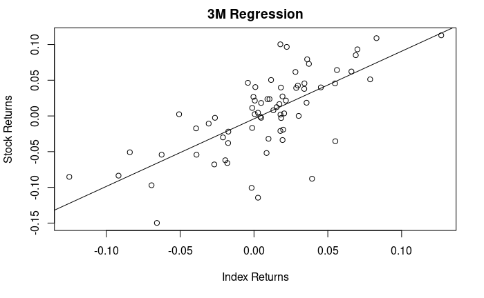

```r
plot.default(x = stock.returns.monthly_xts_4[, 11], y = stock.returns.monthly_xts_4[, 1], main = "3M Regression", xlab = "Index Returns", ylab = "Stock Returns", abline(lm(stock.returns.monthly_xts_4[, 1] ~ stock.returns.monthly_xts_4[, 11])))
```

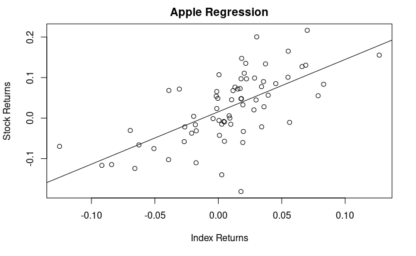

```r
plot.default(x = stock.returns.monthly_xts_4[, 11], y = stock.returns.monthly_xts_4[, 2], main = "Apple Regression", xlab = "Index Returns", ylab = "Stock Returns", abline(lm(stock.returns.monthly_xts_4[, 2] ~ stock.returns.monthly_xts_4[, 11])))
```

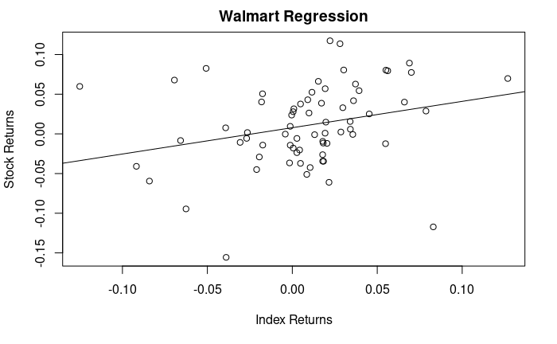

```r
plot.default(x = stock.returns.monthly_xts_4[, 11], y = stock.returns.monthly_xts_4[, 3], main = "Walmart Regression", xlab = "Index Returns", ylab = "Stock Returns", abline(lm(stock.returns.monthly_xts_4[, 3] ~ stock.returns.monthly_xts_4[, 11])))
```

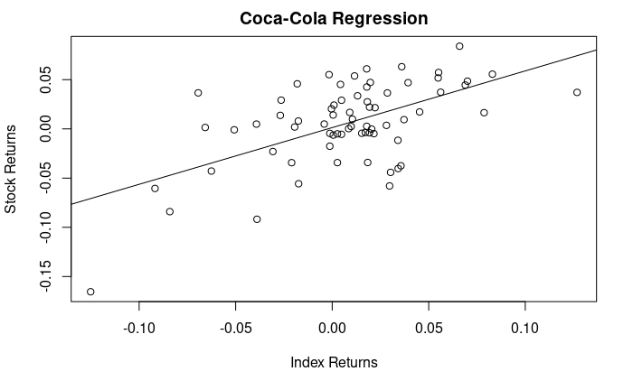

```r
plot.default(x = stock.returns.monthly_xts_4[, 11], y = stock.returns.monthly_xts_4[, 4], main = "Coca-Cola Regression", xlab = "Index Returns", ylab = "Stock Returns", abline(lm(stock.returns.monthly_xts_4[, 4] ~ stock.returns.monthly_xts_4[, 11])))
```

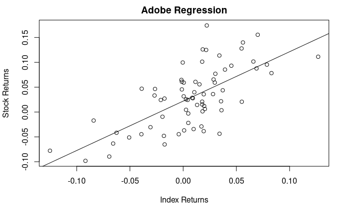

```r
plot.default(x = stock.returns.monthly_xts_4[, 11], y = stock.returns.monthly_xts_4[, 5], main = "Adobe Regression", xlab = "Index Returns", ylab = "Stock Returns", abline(lm(stock.returns.monthly_xts_4[, 5] ~ stock.returns.monthly_xts_4[, 11])))
```

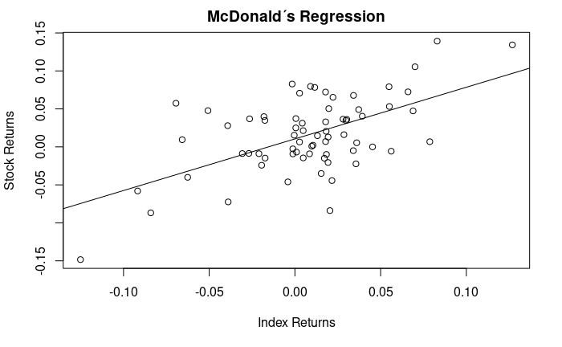

```r
plot.default(x = stock.returns.monthly_xts_4[, 11], y = stock.returns.monthly_xts_4[, 6], main = "McDonald´s Regression", xlab = "Index Returns", ylab = "Stock Returns", abline(lm(stock.returns.monthly_xts_4[, 6] ~ stock.returns.monthly_xts_4[, 11])))
```

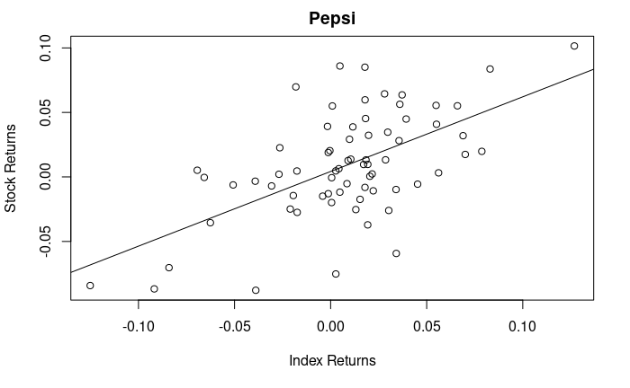

```r
plot.default(x = stock.returns.monthly_xts_4[, 11], y = stock.returns.monthly_xts_4[, 7], main = "Pepsi", xlab = "Index Returns", ylab = "Stock Returns", abline(lm(stock.returns.monthly_xts_4[, 7] ~ stock.returns.monthly_xts_4[, 11])))
```

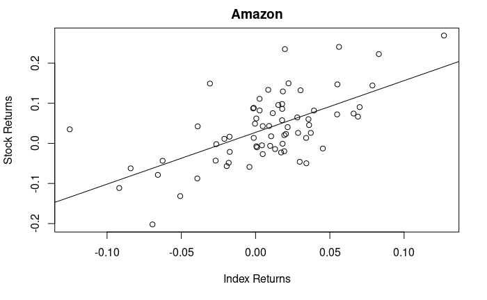

```r
plot.default(x = stock.returns.monthly_xts_4[, 11], y = stock.returns.monthly_xts_4[, 8], main = "Amazon", xlab = "Index Returns", ylab = "Stock Returns", abline(lm(stock.returns.monthly_xts_4[, 8] ~ stock.returns.monthly_xts_4[, 11])))
```

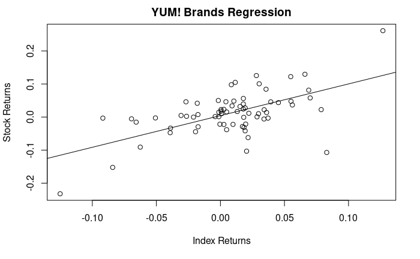

```r
plot.default(x = stock.returns.monthly_xts_4[, 11], y = stock.returns.monthly_xts_4[, 9], main = "YUM! Brands Regression", xlab = "Index Returns", ylab = "Stock Returns", abline(lm(stock.returns.monthly_xts_4[, 9] ~ stock.returns.monthly_xts_4[, 11])))
```

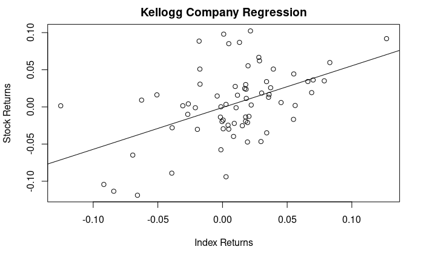

```r
plot.default(x = stock.returns.monthly_xts_4[, 11], y = stock.returns.monthly_xts_4[, 10], main = "Kellogg Company Regression", xlab = "Index Returns", ylab = "Stock Returns", abline(lm(stock.returns.monthly_xts_4[, 10] ~ stock.returns.monthly_xts_4[, 11])))
```

```r
sys.risk <- SystematicRisk(Ra = stock.returns.monthly_xts_4[,-11], Rb = stock.returns.monthly_xts_4[,11], Rf = 0)
sys.risk
```

```
                                        MMM      AAPL        WMT         KO     ADBE        MCD
Systematic Risk to ^GSPC (Rf = 0) 0.1380548 0.1885579 0.04840465 0.08404222 0.145005 0.09920858
                                        PEP      AMZN       YUM          K
Systematic Risk to ^GSPC (Rf = 0) 0.0844475 0.1883617 0.1398555 0.08197276
```

Calculate Firm-specific Risk / Residual Variance

```r
firm.specific.risk <- SpecificRisk(Ra = stock.returns.monthly_xts_4[,-11], Rb = stock.returns.monthly_xts_4[,11], Rf = 0)
firm.specific.risk
```

```
                      MMM      AAPL       WMT        KO     ADBE       MCD       PEP      AMZN
Specific Risk =  0.137794 0.2210535 0.1699435 0.1172385 0.155781 0.1396113 0.1144879 0.2324951
                       YUM         K
Specific Risk =  0.1854363 0.1460486
```

Summary

```r
summary.SFM <- table.SFM(Ra = stock.returns.monthly_xts_4[,-11], Rb = stock.returns.monthly_xts_4[,11], scale = NA, Rf = 0, digits = 6)
summary.SFM
```

|  | MMM to ^GSPC | AAPL to ^GSPC | WMT to ^GSPC | KO to ^GSPC | ADBE to ^GSPC | MCD to ^GSPC | PEP to ^GSPC | AMZN to ^GSPC | YUM to ^GSPC | K to ^GSPC |
| --- | --- | --- | --- | --- | --- | --- | --- | --- | --- | --- |
| Alpha | -0.003982 | 0.015593 | 0.007837 | 0.001314 | 0.021973 | 0.010551 | 0.004234 | 0.027444 | 0.004370 | -0.000845 |
| Beta | 0.946198 | 1.292335 | 0.331755 | 0.576007 | 0.993833 | 0.679954 | 0.578785 | 1.290990 | 0.958540 | 0.561824 |
| Beta+ | 0.974353 | 1.521321 | 0.464334 | 0.429057 | 1.082994 | 0.831517 | 0.597864 | 1.524371 | 1.013427 | 0.563669 |
| Beta- | 0.729792 | 1.181315 | -0.045700 | 0.991808 | 1.131768 | 0.880969 | 0.786826 | 0.965208 | 1.366685 | 0.675683 |
| R-squared | 0.497296 | 0.417609 | 0.074032 | 0.336176 | 0.460591 | 0.332284 | 0.349037 | 0.392788 | 0.359208 | 0.236909 |
| Annualized Alpha | -0.046749 | 0.204022 | 0.098203 | 0.015884 | 0.297990 | 0.134221 | 0.052007 | 0.383884 | 0.053713 | -0.010093 |
| Correlation | 0.705192 | 0.646226 | 0.272089 | 0.579807 | 0.678668 | 0.576441 | 0.590793 | 0.626728 | 0.599340 | 0.486733 |
| Correlation p-value | 0.000000 | 0.000000 | 0.023716 | 0.000000 | 0.000000 | 0.000000 | 0.000000 | 0.000000 | 0.000000 | 0.000022 |
| Tracking Error | 0.139025 | 0.226721 | 0.197007 | 0.133319 | 0.156925 | 0.148184 | 0.130680 | 0.238016 | 0.186893 | 0.160409 |
| Active Premium | -0.064680 | 0.216935 | 0.026849 | -0.026907 | 0.305799 | 0.103539 | 0.011707 | 0.408652 | 0.035147 | -0.058882 |

[output cut: 2 more lines]

2. Extract the betas and calculate systematic and unsystematic risk, derive the whole covariance matrix. To do this you can use *CH15_Factor_Modfels_for_Asset_Returns.pdf (15.3.1)* and the code implemented in the function sharpeFactorEstimator that you find [here](http://financewithr.blogspot.com/2013/06/portfolio-optimization-using-single.html) (please do not just copy everything, but try to understand what you are doing, e.g. check why and if G.hat has the same values as found by the multivariate regression).

Calculate Beta of Portfolio by average each stocks beta

```r
beta.portfolio <- mean(beta.Stocks)
beta.portfolio
```

```
[1] 0.8210222
```

Calculate systematic (Market-Specific) Risk of portfolio

```r
sys.risk.portfolio <- mean(sys.risk)
sys.risk.portfolio
```

```
[1] 0.1197911
```

Calculate unsystematic risk by calculating the mean of the firm-specific risk

```r
unsys.risk.portfolio <- mean(firm.specific.risk)
unsys.risk.portfolio
```

```
[1] 0.161989
```

Calculate Covariance Matrix

```r
stock.returns.monthly_data <- as.data.frame((stock.returns.monthly_xts_4))
data(stock.returns.monthly_data)
```

[output not shown]

```r
returns <- as.timeSeries(stock.returns.monthly_data[,-11])
factors <- as.vector(as.timeSeries(stock.returns.monthly_data)[,11])
names(data)
```

```
 [1] "MMM"  "AAPL" "WMT"  "KO"   "ADBE" "MCD"  "PEP"  "AMZN" "YUM"  "K"
```

```r
data <- returns
attr(data, "factors") <- factors
nScenarios <- nrow(data)
X.mat <- cbind(rep(1, times=nScenarios), factors)
G.hat <- solve(qr(X.mat), data) #G.hat is alpha
beta.hat <- G.hat[2, ] #is beta
eps.hat <- data - X.mat %*% G.hat
diagD.hat <- diag(crossprod(eps.hat) / (nScenarios-2))
cov.si = var(factors)*(beta.hat%o%beta.hat) + diag(diagD.hat)
cov.si
```

```
              MMM        AAPL          WMT           KO         ADBE          MCD          PEP
MMM  0.0032177588 0.002169277 0.0005568746 0.0009668694 0.0016682196 0.0011413519 0.0009715319
AAPL 0.0021692772 0.007156448 0.0007605900 0.0013205687 0.0022784863 0.0015588803 0.0013269370
WMT  0.0005568746 0.000760590 0.0026738257 0.0003390028 0.0005849096 0.0004001797 0.0003406376
KO   0.0009668694 0.001320569 0.0003390028 0.0017681888 0.0010155450 0.0006948091 0.0005914296
ADBE 0.0016682196 0.002278486 0.0005849096 0.0010155450 0.0038348805 0.0011988116 0.0010204423
MCD  0.0011413519 0.001558880 0.0004001797 0.0006948091 0.0011988116 0.0024929571 0.0006981597
             AMZN          YUM            K
MMM  0.0021670194 0.0016089774 0.0009430611
AAPL 0.0029597566 0.0021975721 0.0012880510
WMT  0.0007597983 0.0005641381 0.0003306552
KO   0.0013191943 0.0009794807 0.0005740977
ADBE 0.0022761148 0.0016899790 0.0009905382
MCD  0.0015572577 0.0011562391 0.0006777001
 [ reached getOption("max.print") -- omitted 4 rows ]
```

3. Now use the *custom-moments* functions from Exercise 2 to implement the single-factor model into the portfolio optimization framework and plot the efficient frontier using the parameters estimated by the single factor model next to the EF of the full-covariance model. Calculate MVP, TP etc. and work out the differences in weights, portfolio return and portfolio risk.

```r
#Function to implement single-factor model into the portfolio optimization framework
data(stock.returns.monthly_xts_4)
returns <- as.timeSeries(stock.returns.monthly_xts_4)
names(data)
data <- returns[, -c(11)]
factors <- returns[, 11]
attr(data, "factors") <- factors
# Sharpe's Single Index Factor Model:
sharpeFactorEstimator <-
function(x, spec=NULL, ...)
{
    # Sharpe Single Index Model:
    data <- getDataPart(x)
    factors <- attr(x, "factors")
    nScenarios <- nrow(data)
    X.mat <- cbind(rep(1, times=nScenarios), factors)
    G.hat <- solve(qr(X.mat), data)
    beta.hat <- G.hat[2, ]
    eps.hat <- data - X.mat %*% G.hat
    diagD.hat <- diag(crossprod(eps.hat) / (nScenarios-2))
    mu <- G.hat[1, ] + G.hat[2, ] * colMeans(factors)
    Sigma <- var(factors)[[1]] * (beta.hat %o% beta.hat) + diag(diagD.hat)

    # Return Value:
    list(mu = mu, Sigma = Sigma)
}
spec <- portfolioSpec()
setEstimator(spec) <- "sharpeFactorEstimator"
sharpe <- portfolioFrontier(data, spec)
#Chart the efficient frontier using the parameters estimated by the single factor model
sharpe_1 <- portfolioFrontier(data)
tailoredFrontierPlot(sharpe_1)
points(frontierPoints(sharpe), col = "steelblue")
#Chart Efficient Frontier minimum variance
chart.EfficientFrontier(prt_eff_minv, match.col="StdDev", type="b", rf=NULL, pch.assets = 1)
```

[output not shown]